# testing_distribution_families

## Log Normal Distibution

The original code uses Log Normal distribution. Our goal here is to understand how the author implemented Log Normal distribution. Documentation for log normal distribution may be found at https://stat.ethz.ch/R-manual/R-devel/library/stats/html/Lognormal.html. The author is using **dlnorm** which will return the density. It is my understanding that density is also known as the probability density function. This is a distribution of probabilities. The density function is the derivative of the distribution function, **plnorm**.

An important point is whether we want to look at only continuous probability distributions, or also include discrete probability distributions such as binomial?

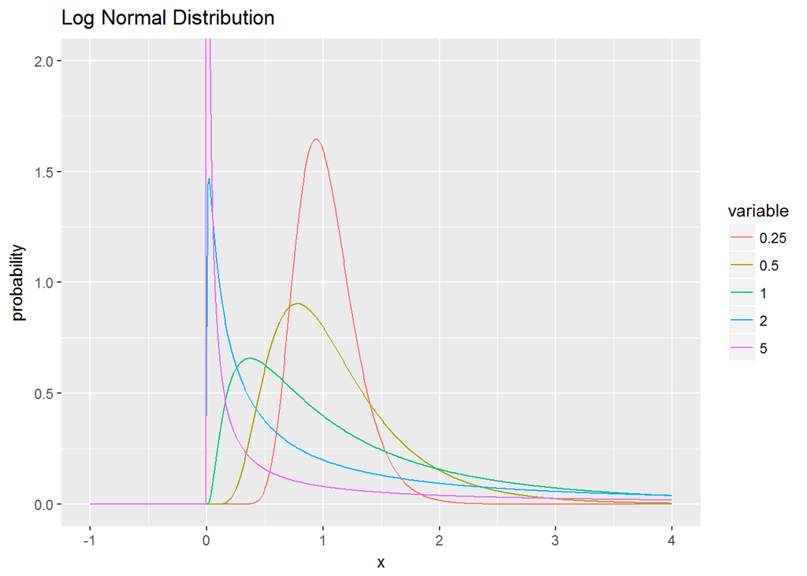

```r
u = 0 # mean around 0, but E(X) will be 1/2*stdev^2

for (s in listStdDev) {
  dat[, as.character(s)] = dlnorm(x, meanlog=u, sdlog=s)
}

d = melt(dat, id.vars="x")
ggplot(d, aes(x=x, y=value, col=variable)) + geom_line() + coord_cartesian(ylim=c(0, 2)) + labs(y="probability") + labs(title="Log Normal Distribution")
```

We see that probability = 0 for all x < 0 which makes sense. The author’s implementation provides a negative value for the parameter **meanlog**. This is done to get E(X) = exp(0) = 1. Let’s see what happens when we do the same.

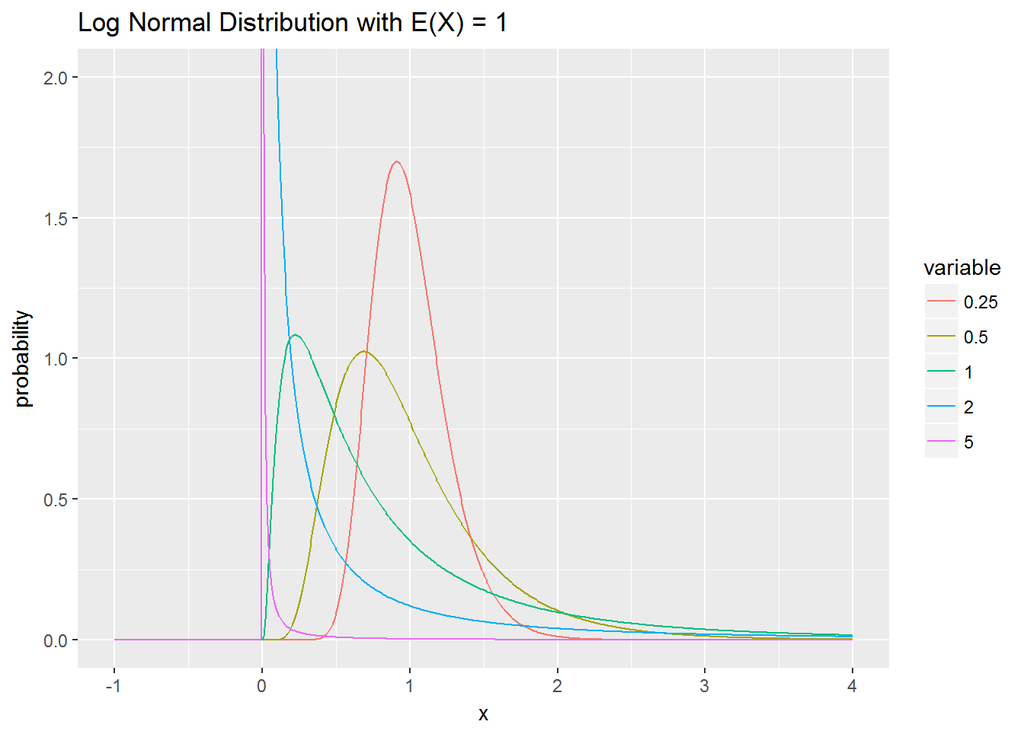

```r
# set mean such that E(X) = 0 or 1

for (s in listStdDev) {
  u = -1/2*s^2
  dat[, as.character(s)] = dlnorm(x, meanlog=u, sdlog=s)
}

d = melt(dat, id.vars="x")
ggplot(d, aes(x=x, y=value, col=variable)) + geom_line() + coord_cartesian(ylim=c(0, 2)) + labs(y="probability") + labs(title="Log Normal Distribution with E(X) = 1")
```

Good, probability = 0 for all x < 0. In this test, we specifically define the mean in terms of the standard deviation, as the author does in the original code.

## Normal distribution

Let’s try to add another distribution. Possibily the most often-used distribution is the normal distribution. The function we are interested in is **dnorm** as described at https://stat.ethz.ch/R-manual/R-devel/library/stats/html/Normal.html. The parameters are similar to log normal distribution in that we may specify the mean (similar to meanlog) and standard deviation (similar to sdlog).

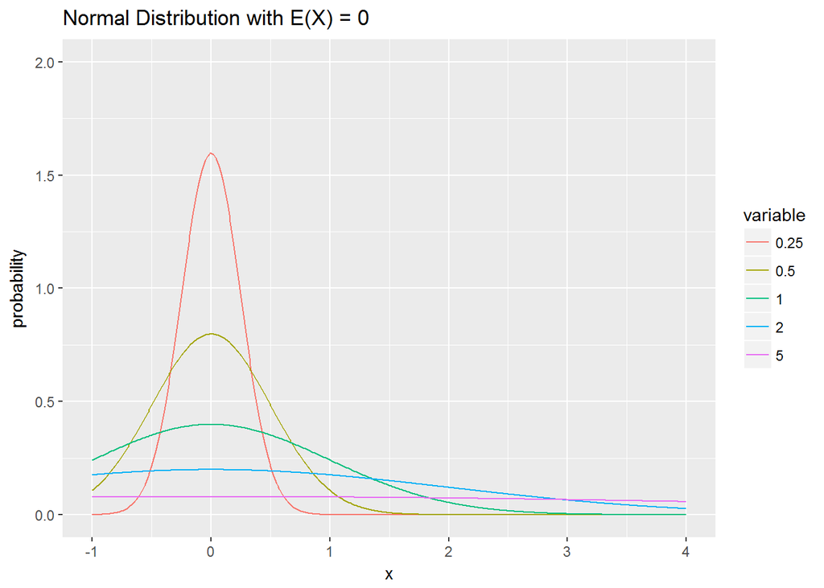

```r
u = 0 # mean around 0, but E(X) will be 1/2*stdev^2

for (s in listStdDev) {
  dat[, as.character(s)] = dnorm(x, mean=u, sd=s)
}

d = melt(dat, id.vars="x")
ggplot(d, aes(x=x, y=value, col=variable)) + geom_line() + coord_cartesian(ylim=c(0, 2)) + labs(y="probability") + labs(title="Normal Distribution with E(X) = 0")
```

With a normal distribution, E(X) = mean = 0. Subsequently, for completeness, we will set the mean to 1.

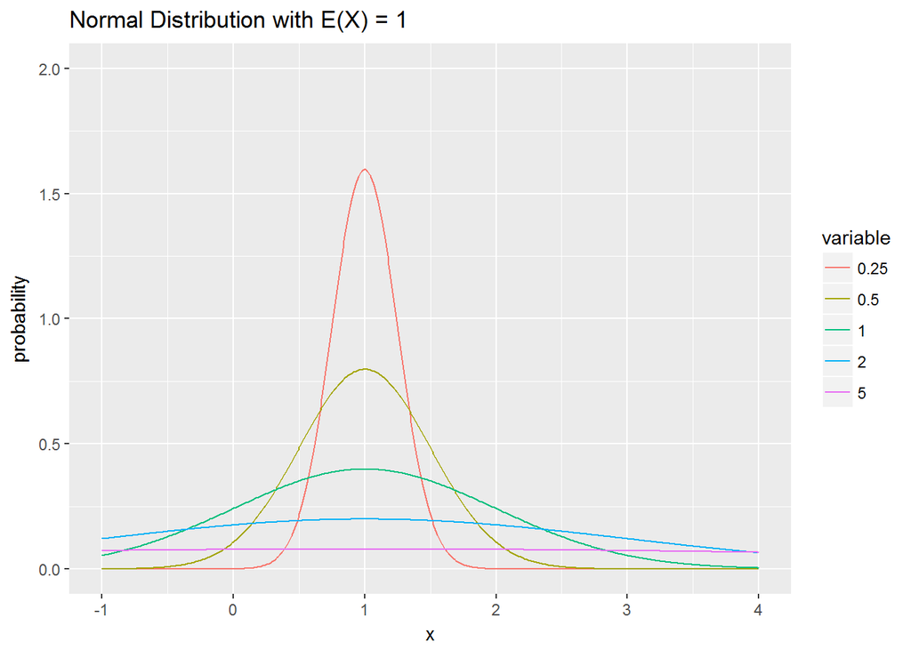

```r
u = 1 # E(X) = 1

for (s in listStdDev) {
  dat[, as.character(s)] = dnorm(x, mean=u, sd=s)
}

d = melt(dat, id.vars="x")
ggplot(d, aes(x=x, y=value, col=variable)) + geom_line() + coord_cartesian(ylim=c(0, 2)) + labs(y="probability") + labs(title="Normal Distribution with E(X) = 1")
```

## Weibull distribution

We will now look at a Weibull distribution. The function we are interested in is **dweibull** as described at https://stat.ethz.ch/R-manual/R-devel/library/stats/html/Weibull.html. The parameters to provide are shape and scale.

Documentation about shape and scale may be found at: http://www.calvin.edu/~stob/courses/m241/F11/outlines/Sept27-Weibull.pdf

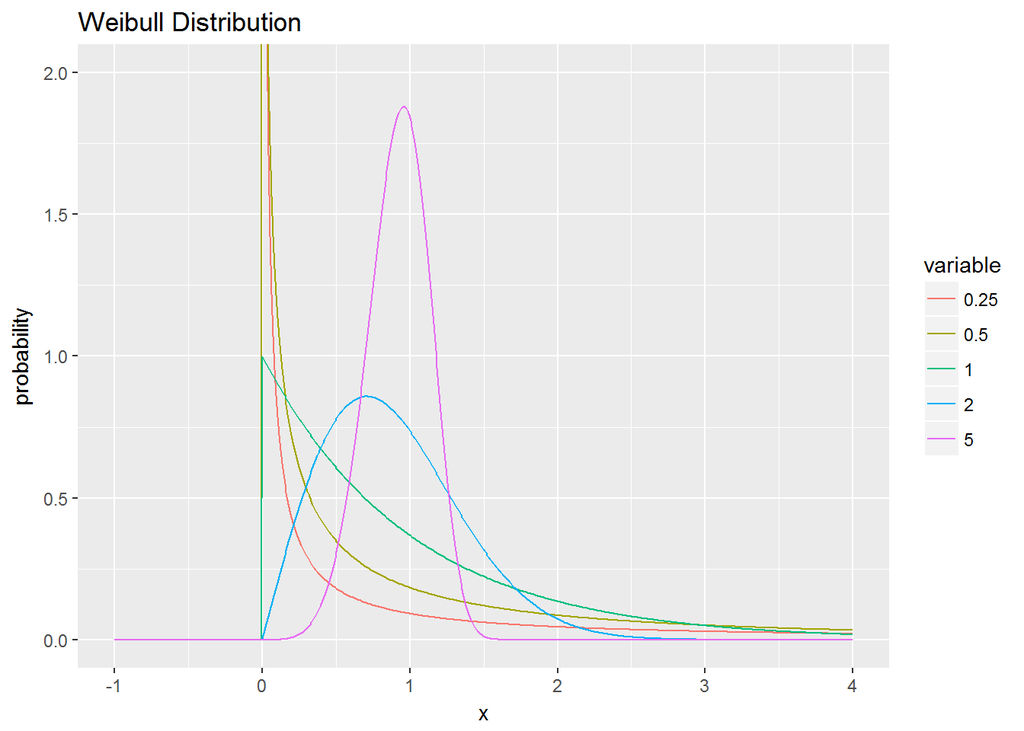

```r
for (s in listStdDev) {
  dat[, as.character(s)] = dweibull(x, shape=s, scale=1)
}

d = melt(dat, id.vars="x")
ggplot(d, aes(x=x, y=value, col=variable)) + geom_line() + coord_cartesian(ylim=c(0, 2)) + labs(y="probability") + labs(title="Weibull Distribution")
```

We have been setting the expected value to 1. For Weibull, E(X) = scale x gamma_function(1/shape + 1). Above, we set shape to be the standard deviation. The gamma function in R is **gamma**. It follows that we should set

E(X) = 1 = scale x gamma( 1/shape +1 )

scale = 1 / gamma( 1/shape + 1 )

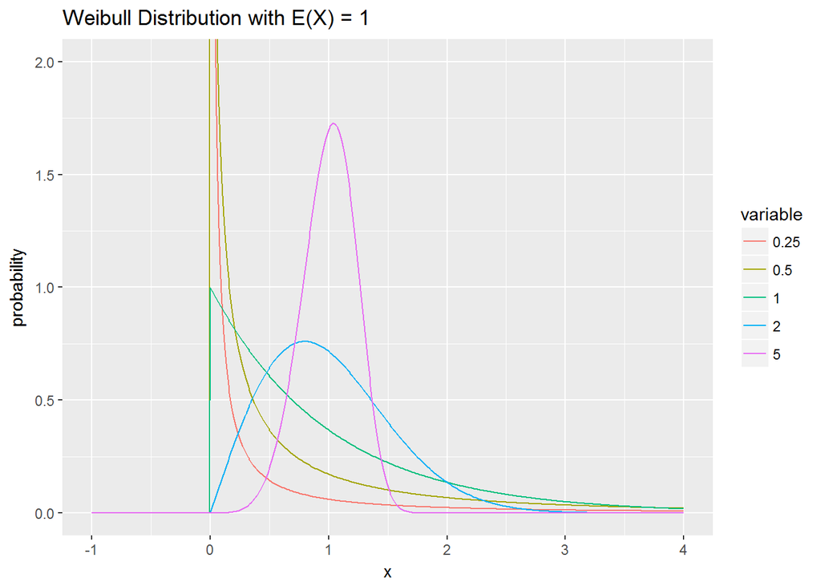

```r
for (s in listStdDev) {
  dat[, as.character(s)] = dweibull(x, shape=s, scale=1/gamma(1/s+1))
}

d = melt(dat, id.vars="x")
ggplot(d, aes(x=x, y=value, col=variable)) + geom_line() + coord_cartesian(ylim=c(0, 2)) + labs(y="probability") + labs(title="Weibull Distribution with E(X) = 1")
```

## Exponential Distribution

The exponential distribution function is **dexp**, https://stat.ethz.ch/R-manual/R-devel/library/stats/html/Exponential.html. The parameter to provide is rate.

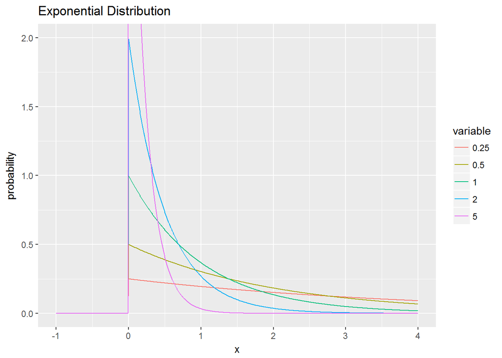

```r
for (s in listStdDev) {
  dat[, as.character(s)] = dexp(x, rate=s)
}

d = melt(dat, id.vars="x")
ggplot(d, aes(x=x, y=value, col=variable)) + geom_line() + coord_cartesian(ylim=c(0, 2)) + labs(y="probability") + labs(title="Exponential Distribution")
```

## Gamma Distribution

The gamma distribution function is **dgamma**, https://stat.ethz.ch/R-manual/R-devel/library/stats/html/GammaDist.html. The parameters to provide are shape and rate.

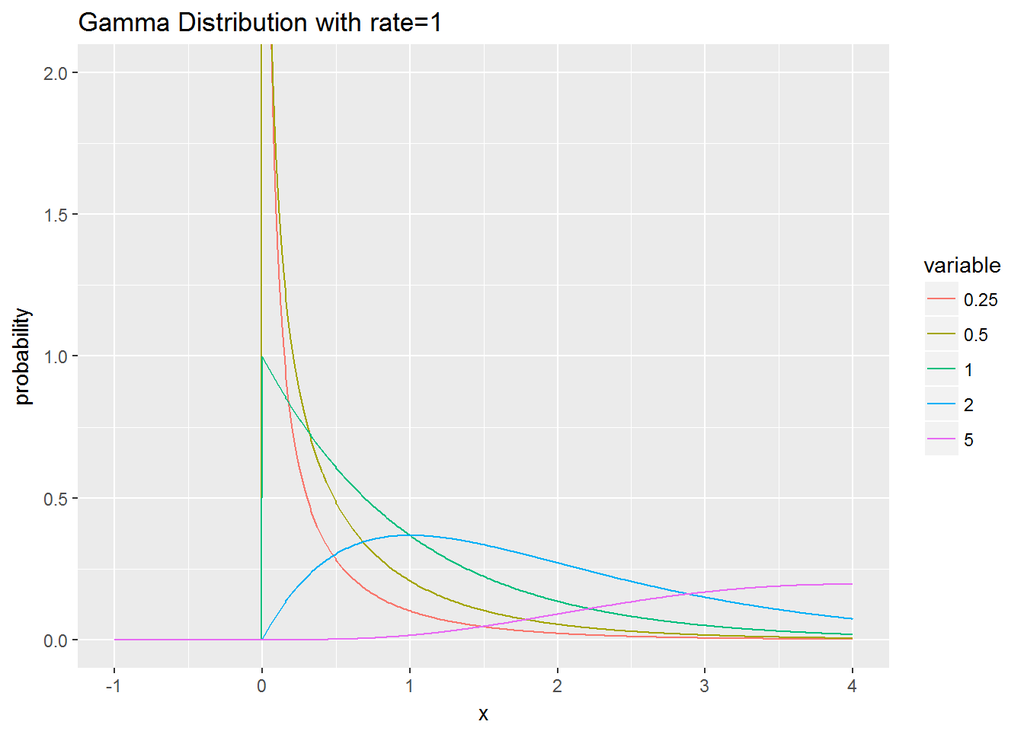

```r
for (s in listStdDev) {
  dat[, as.character(s)] = dgamma(x, shape=s, rate=1)
}

d = melt(dat, id.vars="x")
ggplot(d, aes(x=x, y=value, col=variable)) + geom_line() + coord_cartesian(ylim=c(0, 2)) + labs(y="probability") + labs(title="Gamma Distribution with rate=1")
```

We will now adjust rate such that the expected value equals 1.

E(X) = 1 = shape / rate

rate = shape

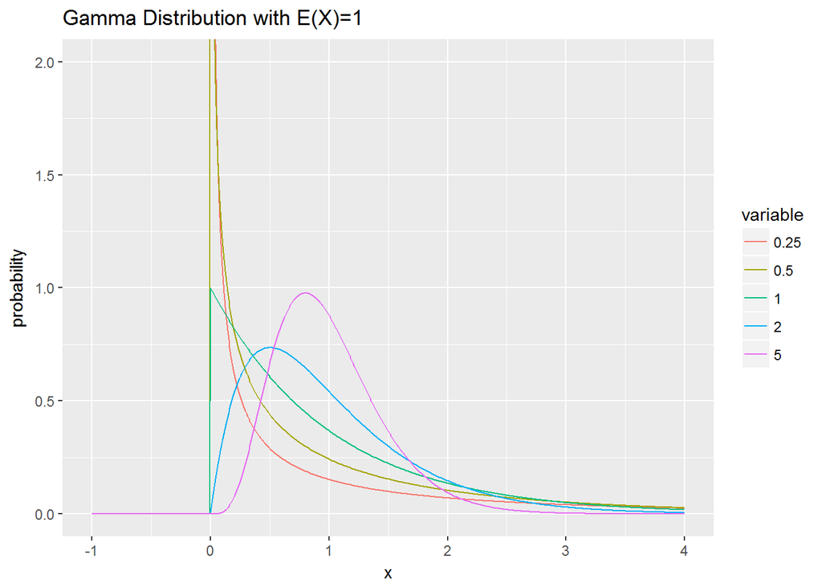

```r
for (s in listStdDev) {
  dat[, as.character(s)] = dgamma(x, shape=s, rate=s)
}

d = melt(dat, id.vars="x")
ggplot(d, aes(x=x, y=value, col=variable)) + geom_line() + coord_cartesian(ylim=c(0, 2)) + labs(y="probability") + labs(title="Gamma Distribution with E(X)=1")
```

## Cauchy Distribution

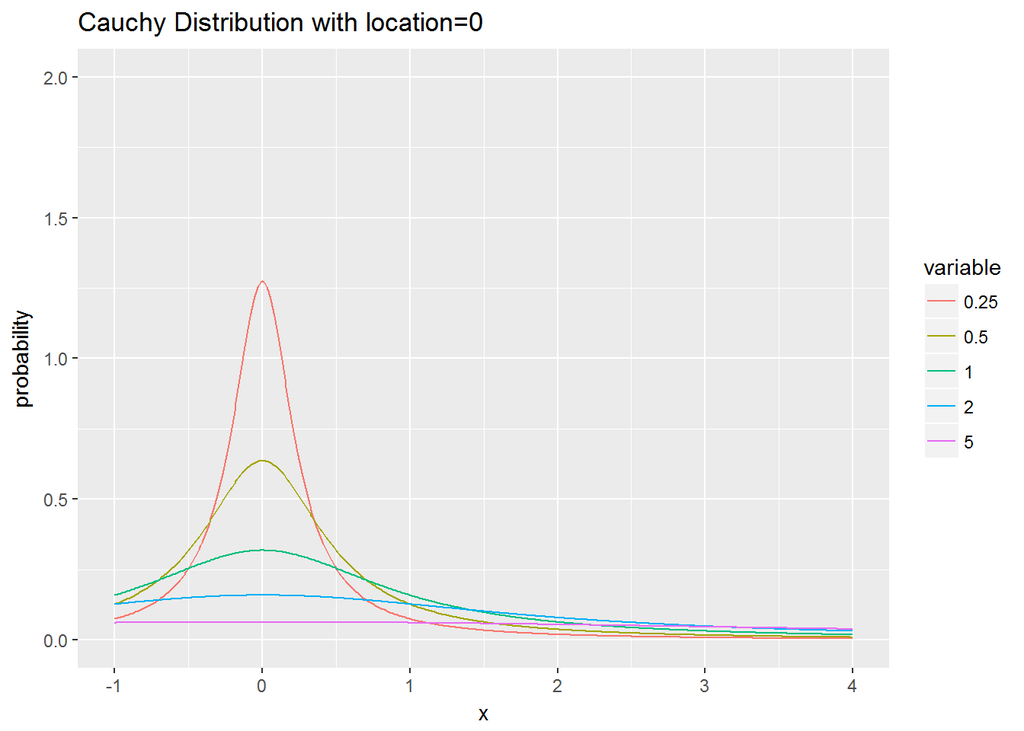

```r
for (s in listStdDev) {
  dat[, as.character(s)] = dcauchy(x, scale=s, location=0)
}

d = melt(dat, id.vars="x")
ggplot(d, aes(x=x, y=value, col=variable)) + geom_line() + coord_cartesian(ylim=c(0, 2)) + labs(y="probability") + labs(title="Cauchy Distribution with location=0")
```

Cauchy distributions do not have an analytical solution regarding expected value. We can however set the leak of the distribution to 1, for fun.

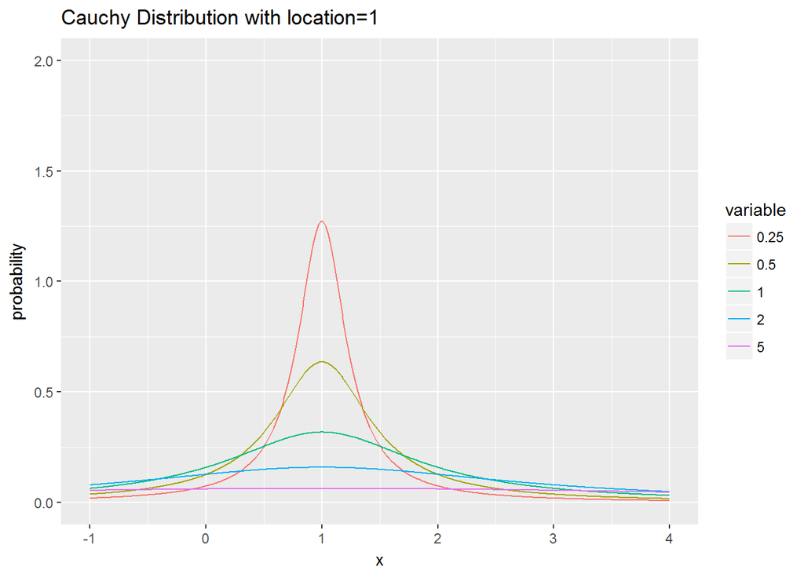

```r
for (s in listStdDev) {
  dat[, as.character(s)] = dcauchy(x, scale=s, location=1)
}

d = melt(dat, id.vars="x")
ggplot(d, aes(x=x, y=value, col=variable)) + geom_line() + coord_cartesian(ylim=c(0, 2)) + labs(y="probability") + labs(title="Cauchy Distribution with location=1")
```

## Chi-Squared Distribution

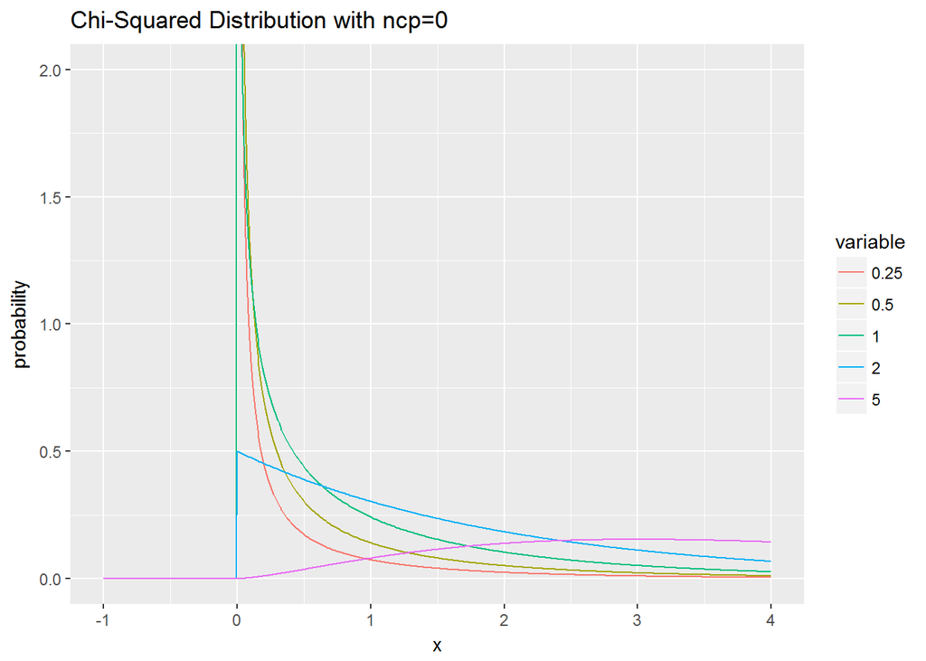

```r
for (s in listStdDev) {
  dat[, as.character(s)] = dchisq(x, df=s, ncp=0)
}

d = melt(dat, id.vars="x")
ggplot(d, aes(x=x, y=value, col=variable)) + geom_line() + coord_cartesian(ylim=c(0, 2)) + labs(y="probability") + labs(title="Chi-Squared Distribution with ncp=0")
```

## Binomial Distribution (not continuous!)

The binomial distribution function is **dbinom**, https://stat.ethz.ch/R-manual/R-devel/library/stats/html/Binomial.html. The parameters to provide are number of trials (non-negative) and probabiltiy of success on each trial. The input parameter, x, must also be integer. Additionally, x may need to be non-negative